# DriveML: Self-Drive machine learning projects

Automated machine learning classification model functions

Dayananda Ubrangala, Sayan Putatunda, Kiran R, Ravi Prasad Kondapalli

2022-12-01

## 1. Introduction

The document introduces the **DriveML** package and how it can help you to build effortless machine learning binary classification models in a short period.

**DriveML** is a series of functions such as `AutoDataPrep`, `AutoMAR`, `autoMLmodel`. **DriveML** automates some of the complicated machine learning functions such as exploratory data analysis, data pre-processing, feature engineering, model training, model validation, model tuning and model selection.

This package automates the following steps on any input dataset for machine learning classification problems

1. Data cleaning
   - Replacing NA, infinite values
   - Removing duplicates
   - Cleaning feature names
2. Feature engineering
   - Missing at random features
   - Missing variable imputation
   - Outlier treatment - Outlier flag and imputation with 5th or 95th percentile value
   - Date variable transformation
   - Bulk interactions for numerical features
   - Frequent transformer for categorical features
   - Categorical feature engineering - one hot encoding
   - Feature selection using zero variance, correlation and AUC method
3. Binary classification - Model training and validation
   - Automated test and validation set creations
   - Hyperparameter tuning using random search
   - Multiple binary classification algorithms like logistic regression, randomForest, xgboost, glmnet, rpart
   - Model validation using AUC value
   - Model plots like training and testing ROC curve, threshold plot
   - Probability scores and model objects
4. Model Explanation
   - Lift plot
   - Partial dependence plot
   - Feature importance plot
5. Model report
   - model output in rmarkdown html format

Additionally, we are providing a function SmartEDA for Exploratory data analysis that generates automated EDA report in HTML format to understand the distributions of the data. Please note there are some dependencies on some other R packages such as MLR, caret, data.table, ggplot2, etc. for some specific task.

To summarize, DriveML package helps in getting the complete Machine learning classification model just by running the function instead of writing lengthy r code.

Algorithm: Missing at random features

1. Select all the missing features X_i where i=1,2,…..,N.
2. For i=1 to N:
   - Define Y_i, which will have value of 1 if X_i has a missing value, 0 if X_i is not having missing value
   - Impute all X_(i+1 ) 〖to X〗_(N ) variables using imputation method
   - Fit binary classifier f_m to the training data using Y_i ~ X_(i+1 ) 〖+⋯+ X〗_(N )
   - Calculate AUC ∝_ivalue between actual Y_i and predicted Y ̂_i
   - If ∝_i is low then the missing values in X_i are missing at random,Y_i to be dropped
   - Repeat steps 1 to 4 for all the independent variables in the original dataset

## 2. Functionalities of DriveML

The DriveML R package has three unique functions

1. Data Pre-processing and Data Preparation
   - `autoDataPrep` function to generate a novel features based on the functional understanding of the dataset
2. Building Machine Learning Models
   - `autoMLmodel` function to develop baseline machine learning models using regression and tree based classification techniques
3. Generating Model Report
   - `autoMLReport` function to print the machine learning model outcome in HTML format

## 3. Machine learning classfication model use-case using DriveML

#### About the dataset

This database contains 76 attributes, but all published experiments refer to using a subset of 14 of them. In particular, the Cleveland database is the only one that has been used by ML researchers to this date. The “goal” field refers to the presence of heart disease in the patient. It is integer valued from 0 (no presence) to 4.

Data Source `https://archive.ics.uci.edu/ml/datasets/Heart+Disease`

Install the package “DriveML” to get the example data set.

```r
library("DriveML")
library("SmartEDA")
## Load sample dataset from ISLR pacakge
data(heart)
```

more detailed attribute information is there in `DriveML` help page

### 3.1 Data Exploration

For data exploratory analysis used `SmartEDA` package

#### Overview of the data

Understanding the dimensions of the dataset, variable names, overall missing summary and data types of each variables

```r
# Overview of the data - Type = 1
ExpData(data=heart,type=1)

# Structure of the data - Type = 2
ExpData(data=heart,type=2)
```

- Overview of the data

  | Descriptions | Value |
  | --- | --- |
  | Sample size (nrow) | 303 |
  | No. of variables (ncol) | 14 |
  | No. of numeric/interger variables | 14 |
  | No. of factor variables | 0 |
  | No. of text variables | 0 |
  | No. of logical variables | 0 |
  | No. of identifier variables | 0 |
  | No. of date variables | 0 |
  | No. of zero variance variables (uniform) | 0 |
  | %. of variables having complete cases | 100% (14) |
  | %. of variables having >0% and <50% missing cases | 0% (0) |
  | %. of variables having >=50% and <90% missing cases | 0% (0) |
  | %. of variables having >=90% missing cases | 0% (0) |

- Structure of the data

| Index | Variable_Name | Variable_Type | Sample_n | Missing_Count | Per_of_Missing | No_of_distinct_values |
| --- | --- | --- | --- | --- | --- | --- |
| 1 | age | integer | 303 | 0 | 0 | 41 |
| 2 | sex | integer | 303 | 0 | 0 | 2 |
| 3 | cp | integer | 303 | 0 | 0 | 4 |
| 4 | trestbps | integer | 303 | 0 | 0 | 49 |
| 5 | chol | integer | 303 | 0 | 0 | 152 |
| 6 | fbs | integer | 303 | 0 | 0 | 2 |
| 7 | restecg | integer | 303 | 0 | 0 | 3 |
| 8 | thalach | integer | 303 | 0 | 0 | 91 |
| 9 | exang | integer | 303 | 0 | 0 | 2 |
| 10 | oldpeak | numeric | 303 | 0 | 0 | 40 |
| 11 | slope | integer | 303 | 0 | 0 | 3 |
| 12 | ca | integer | 303 | 0 | 0 | 5 |
| 13 | thal | integer | 303 | 0 | 0 | 4 |
| 14 | target_var | integer | 303 | 0 | 0 | 2 |

#### Summary of numerical variables

```r
ExpNumStat(heart,by="GA",gp="target_var",Qnt=seq(0,1,0.1),MesofShape=2,Outlier=TRUE,round=2)
```

| Vname | Group | TN | nNeg | nZero | nPos | NegInf | PosInf | NA_Value | Per_of_Missing | sum | min | max | mean | median | SD | CV | IQR | Skewness | Kurtosis | 0% | 10% | 20% | 30% | 40% | 50% | 60% | 70% | 80% | 90% | … |
| --- | --- | --- | --- | --- | --- | --- | --- | --- | --- | --- | --- | --- | --- | --- | --- | --- | --- | --- | --- | --- | --- | --- | --- | --- | --- | --- | --- | --- | --- | --- |
| age | target_var:All | 303 | 0 | 0 | 303 | 0 | 0 | 0 | 0 | 16473.0 | 29 | 77.0 | 54.37 | 55.0 | 9.08 | 0.17 | 13.50 | -0.20 | -0.55 | 29 | 42.0 | 45.00 | 50.0 | 53.00 | 55.0 | 58.00 | 59.00 | 62.0 | 66.0 | … |
| age | target_var:1 | 165 | 0 | 0 | 165 | 0 | 0 | 0 | 0 | 8662.0 | 29 | 76.0 | 52.50 | 52.0 | 9.55 | 0.18 | 15.00 | 0.12 | -0.63 | 29 | 41.0 | 43.00 | 46.0 | 50.60 | 52.0 | 54.00 | 57.80 | 62.0 | 65.6 | … |
| age | target_var:0 | 138 | 0 | 0 | 138 | 0 | 0 | 0 | 0 | 7811.0 | 35 | 77.0 | 56.60 | 58.0 | 7.96 | 0.14 | 10.00 | -0.54 | 0.08 | 35 | 44.7 | 50.00 | 54.0 | 56.80 | 58.0 | 59.00 | 61.00 | 63.0 | 66.0 | … |
| chol | target_var:All | 303 | 0 | 0 | 303 | 0 | 0 | 0 | 0 | 74618.0 | 126 | 564.0 | 246.26 | 240.0 | 51.83 | 0.21 | 63.50 | 1.14 | 4.41 | 126 | 188.0 | 204.00 | 217.6 | 230.00 | 240.0 | 254.00 | 268.00 | 285.2 | 308.8 | … |
| chol | target_var:1 | 165 | 0 | 0 | 165 | 0 | 0 | 0 | 0 | 39968.0 | 126 | 564.0 | 242.23 | 234.0 | 53.55 | 0.22 | 59.00 | 1.73 | 7.37 | 126 | 192.0 | 202.60 | 212.2 | 223.00 | 234.0 | 245.00 | 260.80 | 273.4 | 305.2 | … |
| chol | target_var:0 | 138 | 0 | 0 | 138 | 0 | 0 | 0 | 0 | 34650.0 | 131 | 409.0 | 251.09 | 249.0 | 49.45 | 0.20 | 65.75 | 0.31 | 0.32 | 131 | 187.7 | 206.40 | 225.3 | 235.60 | 249.0 | 261.40 | 275.90 | 289.0 | 312.2 | … |
| oldpeak | target_var:All | 303 | 0 | 99 | 204 | 0 | 0 | 0 | 0 | 315.0 | 0 | 6.2 | 1.04 | 0.8 | 1.16 | 1.12 | 1.60 | 1.26 | 1.53 | 0 | 0.0 | 0.00 | 0.0 | 0.38 | 0.8 | 1.12 | 1.40 | 1.9 | 2.8 | … |
| oldpeak | target_var:1 | 165 | 0 | 74 | 91 | 0 | 0 | 0 | 0 | 96.2 | 0 | 4.2 | 0.58 | 0.2 | 0.78 | 1.34 | 1.00 | 1.63 | 3.06 | 0 | 0.0 | 0.00 | 0.0 | 0.00 | 0.2 | 0.50 | 0.80 | 1.2 | 1.6 | … |
| oldpeak | target_var:0 | 138 | 0 | 25 | 113 | 0 | 0 | 0 | 0 | 218.8 | 0 | 6.2 | 1.59 | 1.4 | 1.30 | 0.82 | 1.90 | 0.73 | 0.35 | 0 | 0.0 | 0.14 | 0.8 | 1.00 | 1.4 | 1.80 | 2.19 | 2.8 | 3.4 | … |
| thalach | target_var:All | 303 | 0 | 0 | 303 | 0 | 0 | 0 | 0 | 45343.0 | 71 | 202.0 | 149.65 | 153.0 | 22.91 | 0.15 | 32.50 | -0.53 | -0.08 | 71 | 116.0 | 130.00 | 140.6 | 146.00 | 153.0 | 159.00 | 163.00 | 170.0 | 176.6 | … |

[output cut: 5 more lines]

#### Distributions of Numerical variables

Box plots for all numerical variables vs categorical dependent variable - Bivariate comparison only with classes

Boxplot for all the numerical attributes by each class of the **target variable**

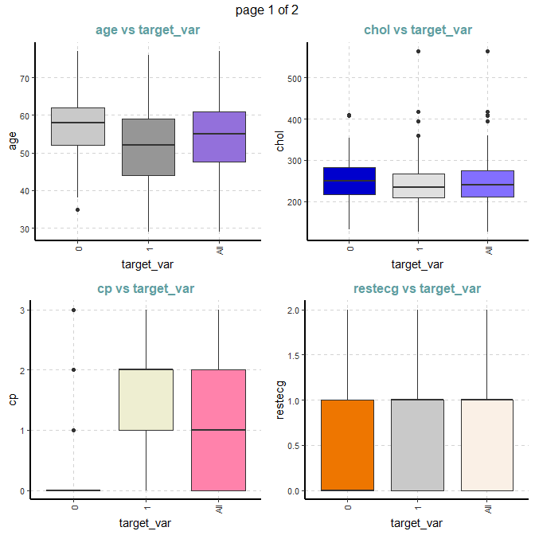

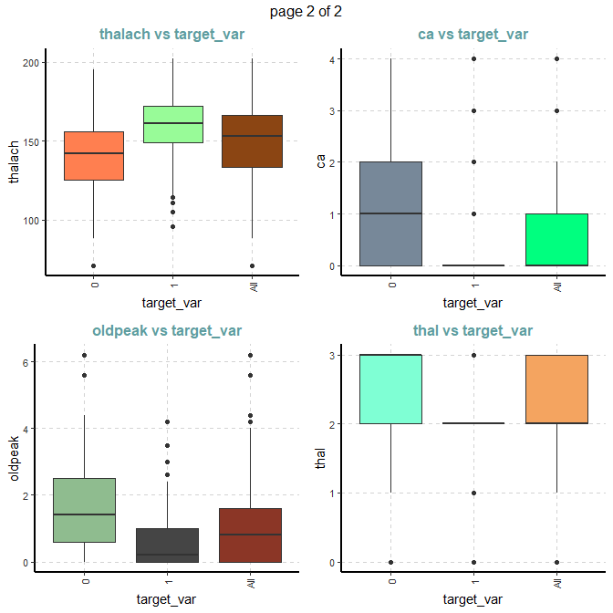

```r
plot4 <- ExpNumViz(heart,target="target_var",type=1,nlim=3,fname=NULL,Page=c(2,2),sample=8)
plot4[[1]]
```

#### Summary of categorical variables

Custom tables between all categorical independent variables and the target variable

```r
ExpCTable(Carseats,Target="Urban",margin=1,clim=10,nlim=3,round=2,bin=NULL,per=F)
```

[output not shown]

#### Distributions of categorical variables

Stacked bar plot with vertical or horizontal bars for all categorical variables

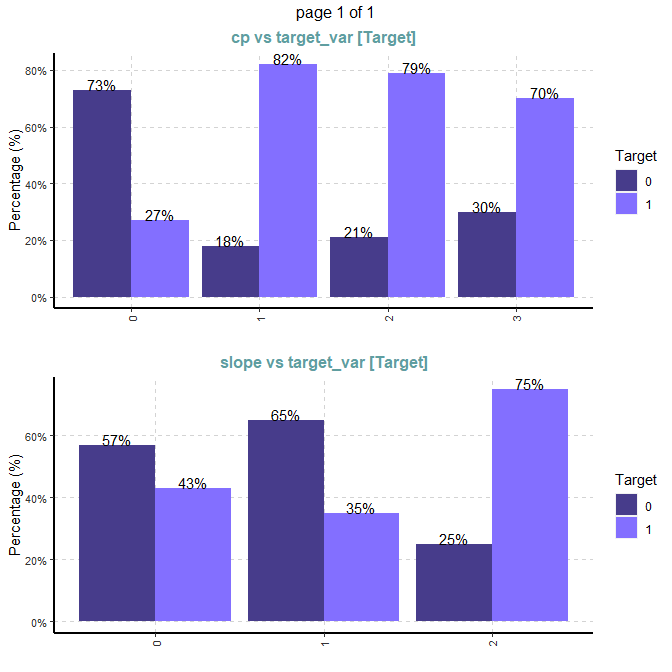

```r
plot5 <- ExpCatViz(heart,target = "target_var", fname = NULL, clim=5,col=c("slateblue4","slateblue1"),margin=2,Page = c(2,1),sample=2)
plot5[[1]]
```

#### Outlier analysis using boxplot

```r
ExpOutliers(heart, varlist = c("oldpeak","trestbps","chol"), method = "boxplot",  treatment = "mean", capping = c(0.1, 0.9))
```

| Category | oldpeak | trestbps | chol |
| --- | --- | --- | --- |
| Lower cap : 0.1 | 0 | 110 | 188 |
| Upper cap : 0.9 | 2.8 | 152 | 308.8 |
| Lower bound | -2.4 | 90 | 115.75 |
| Upper bound | 4 | 170 | 369.75 |
| Num of outliers | 5 | 9 | 5 |
| Lower outlier case |  |  |  |
| Upper outlier case | 102,205,222,251,292 | 9,102,111,204,224,242,249,261,267 | 29,86,97,221,247 |
| Mean before | 1.04 | 131.62 | 246.26 |
| Mean after | 0.97 | 130.1 | 243.04 |
| Median before | 0.8 | 130 | 240 |
| Median after | 0.65 | 130 | 240 |

### 3.2 Data preparations using `autoDataprep`

**Data preparation using DriveML autoDataprep function with default options**

```r
dateprep <- autoDataprep(data = heart,
                         target = 'target_var',
                         missimpute = 'default',
                         auto_mar = FALSE,
                             mar_object = NULL,
                             dummyvar = TRUE,
                             char_var_limit = 15,
                             aucv = 0.002,
                             corr = 0.98,
                             outlier_flag = TRUE,
                             uid = NULL,
                             onlykeep = NULL,
                             drop = NULL)

train_data <- dateprep$master_data
```

**We can use different types of missing imputation using mlr::impute function**

```r
myimpute <- list(classes=list(factor = imputeMode(),
                              integer = imputeMean(),
                              numeric = imputeMedian(),
                              character = imputeMode()))
dateprep <- autoDataprep(data = heart,
                         target = 'target_var',
                         missimpute = myimpute,
                         auto_mar = FALSE,
                             mar_object = NULL,
                             dummyvar = TRUE,
                             char_var_limit = 15,
                             aucv = 0.002,
                             corr = 0.98,
                             outlier_flag = TRUE,
                             uid = NULL,
                             onlykeep = NULL,
                             drop = NULL)

train_data <- dateprep$master_data
```

**Adding Missing at Random features using autoMAR function**

```r
marobj <- autoMAR (heart, aucv = 0.9, strataname = NULL, stratasize = NULL, mar_method = "glm")
```

```
## less than or equal to one missing value coloumn found in the dataframe
```

```r
dateprep <- autoDataprep(data = heart,
                         target = 'target_var',
                         missimpute = myimpute,
                         auto_mar = TRUE,
                             mar_object = marobj,
                             dummyvar = TRUE,
                             char_var_limit = 15,
                             aucv = 0.002,
                             corr = 0.98,
                             outlier_flag = TRUE,
                             uid = NULL,
                             onlykeep = NULL,
                             drop = NULL)

train_data <- dateprep$master_data
```

### 3.3 Machine learning models using `autoMLmodel`

Automated training, tuning and validation of machine learning models. This function includes the following binary classification techniques

```
+ Logistic regression - logreg
+ Regularised regression - glmnet
+ Extreme gradient boosting - xgboost
+ Random forest - randomForest
+ Random forest - ranger
+ Decision tree - rpart
```

```r
mymodel <- autoMLmodel( train = heart,
                        test = NULL,
                        target = 'target_var',
                        testSplit = 0.2,
                        tuneIters = 100,
                        tuneType = "random",
                        models = "all",
                        varImp = 10,
                        liftGroup = 50,
                        maxObs = 4000,
                        uid = NULL,
                        htmlreport = FALSE,
                        seed = 1991)
```

### 3.3 Model output

Model performance

| Model | Fitting time | Scoring time | Train AUC | Test AUC | Accuracy | Precision | Recall | F1_score |
| --- | --- | --- | --- | --- | --- | --- | --- | --- |
| glmnet | 17.12 secs | 0.006 secs | 0.928 | 0.908 | 0.820 | 0.824 | 0.848 | 0.836 |
| logreg | 22.621 secs | 0.005 secs | 0.929 | 0.906 | 0.820 | 0.824 | 0.848 | 0.836 |
| randomForest | 29.739 secs | 0.015 secs | 0.996 | 0.905 | 0.803 | 0.784 | 0.879 | 0.829 |
| ranger | 25.687 secs | 0.053 secs | 0.999 | 0.894 | 0.803 | 0.784 | 0.879 | 0.829 |
| xgboost | 30.449 secs | 0 secs | 0.999 | 0.883 | 0.754 | 0.765 | 0.788 | 0.776 |
| rpart | 19.726 secs | 0 secs | 0.932 | 0.857 | 0.803 | 0.818 | 0.818 | 0.818 |

Randomforest model Receiver Operating Characteristic (ROC) and the variable Importance

Training dataset ROC

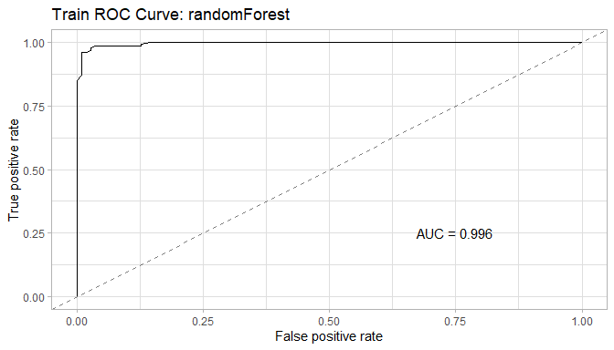

```r
TrainROC <- mymodel$trainedModels$randomForest$modelPlots$TrainROC
TrainROC
```

Test dataset ROC

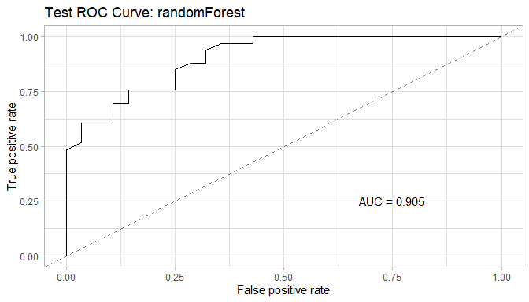

```r
TestROC <- mymodel$trainedModels$randomForest$modelPlots$TestROC
TestROC
```

Variable importance

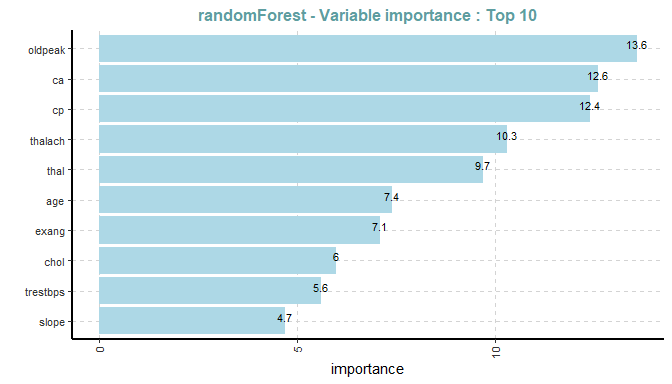

```r
VarImp <- mymodel$trainedModels$randomForest$modelPlots$VarImp
VarImp
```

Threshold

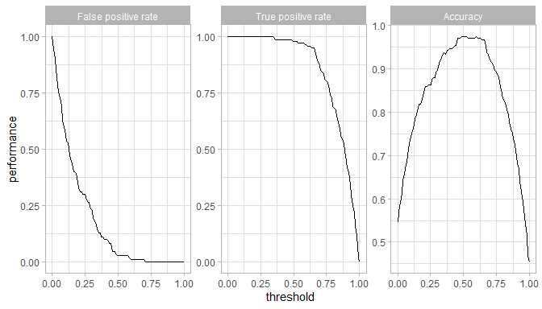

```r
Threshold <- mymodel$trainedModels$randomForest$modelPlots$Threshold
Threshold
```